# Tidying and Modeling Euteleostomi and Drosophila AA and NT Data

### Let’s Try to Tidy `output_selectome/` Data!

So, what we’re trying to do first is to merge all the .csv files in `output_selectome/` into one big .csv file. Then we’re going to tidy that data, by tidying it by species, name, data type, and number of models. Maybe we’ll add tidying parameters as we go along, but let’s see!

Below will be some R code that’s in the works, as of February 4th, 2020.

```r
csv_directory = "../output_selectome"
csv_files <- dir(path=csv_directory,pattern="*.csv")
# Reading in all the .csv files from `output_selectome/` directory
```

After reading in the data, we need to read the actual files. The code below is to read what’s in the files and merge them into one data frame.

```r
csv_dataframe <- read_csv("../results/all_selectome_output_csvs.csv")
csv_dataframe
```

```
## # A tibble: 141,750 x 6
##    filename               name            datatype AIC      AICc    BIC
##    <chr>                  <chr>           <chr>    <chr>    <chr>   <chr>
##  1 EMGT00050000000002.Dr… EMGT0005000000… AA       Dayhoff… Dayhof… Dayhof…
##  2 EMGT00050000000002.Dr… EMGT0005000000… AA       Dayhoff… Dayhof… Dayhof…
##  3 EMGT00050000000002.Dr… EMGT0005000000… AA       JTT+F+I… JTT+F+… JTT+F+…
##  4 EMGT00050000000002.Dr… EMGT0005000000… AA       DCMut+F… DCMut+… DCMut+…
##  5 EMGT00050000000002.Dr… EMGT0005000000… AA       JTT+F+G4 JTT+F+… JTT+F+…
##  6 EMGT00050000000002.Dr… EMGT0005000000… AA       DCMut+F… DCMut+… Dayhof…
##  7 EMGT00050000000002.Dr… EMGT0005000000… AA       JTT+F+I… JTT+F+… JTT+F+…
##  8 EMGT00050000000002.Dr… EMGT0005000000… AA       JTT+F+I… JTT+F+… JTT+F+…
##  9 EMGT00050000000002.Dr… EMGT0005000000… AA       JTT+F+I… JTT+F+… JTT+F+…
## 10 EMGT00050000000002.Dr… EMGT0005000000… AA       Dayhoff… Dayhof… Dayhof…
## # … with 141,740 more rows
```

So I created a variable called `csv_dataframe` which includes all the csv files in one data frame. From here, I will be manipulating that data frame in the code below.

## Wrangle the Hell Out of this Data

So far, as of February 6th, 2020, I cleaned up the .csv by removing the variables `filename` and separating the `name` variable into `name` and `species` and deleting the transcription number that isn’t needed. The ultimate goal for this .rmd is to create four separate plots separated by species and data type, so two Euteleostomi AA and NT and two Drosohpila AA and NT.

Let’s try to gather the ic_type data now!

Ok, the ic_type data is now wrangled, with one column for the ic_type and and one column as the model. Time to rank the models, so then we can start plotting!

```r
csv_dataframe %>%
  separate (name,c("name","species","STOP"),sep="[.]") %>%
  dplyr::select(-filename,-STOP) %>%
  pivot_longer(AIC:BIC, names_to = "ic_type", values_to = "model") -> selected_models
selected_models
```

```
## # A tibble: 425,250 x 5
##    name               species    datatype ic_type model
##    <chr>              <chr>      <chr>    <chr>   <chr>
##  1 EMGT00050000000002 Drosophila AA       AIC     Dayhoff+F+I+G4
##  2 EMGT00050000000002 Drosophila AA       AICc    Dayhoff+F+I+G4
##  3 EMGT00050000000002 Drosophila AA       BIC     Dayhoff+F+G4
##  4 EMGT00050000000002 Drosophila AA       AIC     Dayhoff+F+I+G4
##  5 EMGT00050000000002 Drosophila AA       AICc    Dayhoff+F+I+G4
##  6 EMGT00050000000002 Drosophila AA       BIC     Dayhoff+F+G4
##  7 EMGT00050000000002 Drosophila AA       AIC     JTT+F+I+G4
##  8 EMGT00050000000002 Drosophila AA       AICc    JTT+F+I+G4
##  9 EMGT00050000000002 Drosophila AA       BIC     JTT+F+G4
## 10 EMGT00050000000002 Drosophila AA       AIC     DCMut+F+G4
## # … with 425,240 more rows
```

The data frame is now wrangled and tidied, by putting all the information criterions into its own column, and putting the corresponding model in its own column.

```r
selected_models %>%
  group_by(name,species,datatype,ic_type) %>%
  mutate(total = n() )%>%
  ungroup() %>%
  group_by(name,species,datatype,ic_type, model) %>%
  mutate(n = n()) %>%
  mutate(percent_top_model = n/total) -> percent_selected_models
percent_selected_models
```

```
## # A tibble: 425,250 x 8
## # Groups:   name, species, datatype, ic_type, model [15,041]
##    name      species  datatype ic_type model   total     n percent_top_mod…
##    <chr>     <chr>    <chr>    <chr>   <chr>   <int> <int>            <dbl>
##  1 EMGT0005… Drosoph… AA       AIC     Dayhof…    50    10             0.2
##  2 EMGT0005… Drosoph… AA       AICc    Dayhof…    50    10             0.2
##  3 EMGT0005… Drosoph… AA       BIC     Dayhof…    50    17             0.34
##  4 EMGT0005… Drosoph… AA       AIC     Dayhof…    50    10             0.2
##  5 EMGT0005… Drosoph… AA       AICc    Dayhof…    50    10             0.2
##  6 EMGT0005… Drosoph… AA       BIC     Dayhof…    50    17             0.34
##  7 EMGT0005… Drosoph… AA       AIC     JTT+F+…    50    19             0.38
##  8 EMGT0005… Drosoph… AA       AICc    JTT+F+…    50    19             0.38
##  9 EMGT0005… Drosoph… AA       BIC     JTT+F+…    50    21             0.42
## 10 EMGT0005… Drosoph… AA       AIC     DCMut+…    50     3             0.06
## # … with 425,240 more rows
```

With the top model percentage wrangled, this data can plotted against other data properties!

```r
### another tibble with total number of models per ictype/datatype/name/species
selected_models %>%
  group_by(name,species,datatype,ic_type) %>%
  mutate(total = n() ) %>%
  group_by(ic_type,model) %>%
  tally() %>%
  ungroup()
```

```
## # A tibble: 343 x 3
##    ic_type model              n
##    <chr>   <chr>          <int>
##  1 AIC     cpREV+F+G4        49
##  2 AIC     cpREV+F+I+G4       5
##  3 AIC     Dayhoff+F+G4     418
##  4 AIC     Dayhoff+F+I       12
##  5 AIC     Dayhoff+F+I+G4   296
##  6 AIC     Dayhoff+G4         2
##  7 AIC     DCMut+F+G4       321
##  8 AIC     DCMut+F+I         14
##  9 AIC     DCMut+F+I+G4     444
## 10 AIC     DCMut+G4           2
## # … with 333 more rows
```

```r
### Don't worry about this chunk yet, will work on it later
  #dplyr::select(-n) %>%
  ##rename(most_common_model = model)

  #group_by(name, number, ic_type) %>%
  #mutate(ic_rank = rank(ic_value)) %>%
  #filter(ic_rank == 1) %>%
  #ungroup() %>%
  #dplyr::select(name, number, Model, ic_type)
```

## Let’s Start Plotting!

### Number of Models per Dataset

Alright, so I have the selected models, and the top model percentage calculated. I’m now going to start plotting separate datasets from the `selected_models` dataet. I will try to be finding dataset names that have multiple models selected for itself. I will also be looking for a dataset name that has one model selected for it by data type.

## How many models are selected for

Time to start plotting total number of models per all datasets pertaining to specific species and data type (Euteleostomi or Drosophila and AA or NT)

The function below takes in three arguments. The first is the dataset that needs to be read in, the second is the indicated species, and the third is the indicated datatype. The data is wrangled in this function to indicate how many datasets are selected for ‘n’ amount of models.

```r
process_ggplot_ready_data <- function(dataset,a_species,a_datatype)
{
  dataset %>%
    filter(species==a_species,datatype==a_datatype)%>%
    group_by(name,model,ic_type,datatype) %>%
    tally() %>%
    ungroup() %>%
    select(-n) %>%
    group_by(name,ic_type) %>%
    tally() %>%
    rename(number_datasets = n ) %>%
    group_by(number_datasets, ic_type) %>%
    tally() %>%
    rename(number_of_models = n) -> ready_data
  ready_data

}
```

After the data is processed in the function above, it needs to be plotted. The function below plots data, with one argument, the ready data.

```r
plot_processed_alignments <- function(ready_data)
{


  ready_data %>%
  ggplot(aes(x=number_datasets,y=number_of_models,width=.86)) +
    geom_col() +
    geom_text(aes(x = number_datasets, y = number_of_models + 1, label = number_of_models),size=3,hjust=.5,vjust=.01)+
    facet_wrap(~ic_type) +
    xlab("Number of Datasets") +
    ylab("Number of Selected Models") +
    theme_linedraw()  +
    scale_x_continuous(breaks=seq(0,20,1))+
    theme(plot.title=element_text(hjust=0.5))-> plotted_data
  plotted_data

}
```

Below are the variables that are going to be used as arguments for our functions.

```r
flies <- "Drosophila"
bony<- "Euteleostomi"
amino<-"AA"
nuc<- "NT"
```

### Drosophila AA Number of Models

```r
dros_aa <-process_ggplot_ready_data(selected_models,flies,amino)
daa_plot <- plot_processed_alignments(dros_aa)
```

### Drosophila NT Number of Models

```r
dros_nt <-process_ggplot_ready_data(selected_models,flies,nuc)
dnt_plot <- plot_processed_alignments(dros_nt)
```

### Euteleostomi AA Number of Models

```r
eut_aa <-process_ggplot_ready_data(selected_models,bony,amino)
eaa_plot <-plot_processed_alignments(eut_aa)
```

### Euteleostomi NT Number of Models

```r
eut_nt <- process_ggplot_ready_data(selected_models,bony,nuc)
ent_plot <-plot_processed_alignments(eut_nt)
```

```r
###Notes for future work

#One color for aa and nt or one color for species

#percentage of the time that the GIVEN was the best model out of 50.
#do this 3x; for the 3 most common MODELS, for each criterion, for each aa/nt for each dros/eutel = 36 plots?. no more htan 6 plots in a grid. only applies when >= 3 models.

#how do we do?
#count( dataytpe, ictype, species, name, model)
#count is shortcut for groupby,tally, and ungroup()
#3filter for one, filter for two, filter for three
#only do this for datasets that have three models, lots of wrangling!
##start to wrangle on paper!!!!!


#mutate a new column, determine if it is the top model, then sum by group by, tally, model, rank
#percentage of time the first one occurs
```

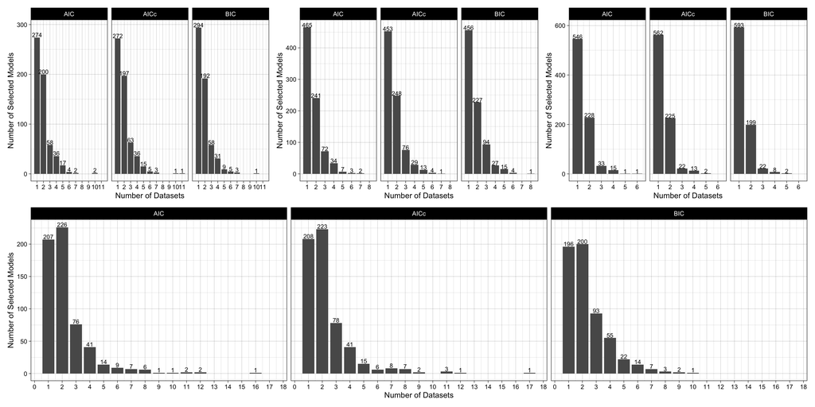

```r
(daa_plot|ent_plot|eaa_plot)/dnt_plot
```

`percent_selected_models` is a variable that defines a tibble of the top model selected per dataset. I think I want to use this variable instead of selected models because it already has the known top model and the percentage it is shown in the dataset. It is April 4th, and I grouped the columns of interest together. I am trying to find a way to make a variable that counts the number of models each dataset contains.

```r
percent_selected_models %>%
  group_by(name,model,species,datatype,ic_type)%>%
  tally() %>%
  ungroup() %>%
  select(-n) %>%
  group_by(name,species,datatype,ic_type) %>%
  tally() %>%
  ungroup() %>%
  filter(n>=3) -> temp_wrang_model
```